# LIU,HONGYANG-17201091-Q1&Q2&Q3&4

Explain Video Link Q1 & Q2: https://drive.google.com/file/d/1zu-Yk6b57rPoFyw8g3H165IiiBgAwN-S/view

Explain Video Link Q3 & Q4: https://drive.google.com/file/d/1gwI6rBtY4PIWR9yt8BE0JJjFFjhoqNMM/view

Name: LIU,HONGYANG 17201091/1

### Q1:

1. You are required to make a user-agent that will crawl the WWW (your familiar domain) to produce dataset of a particular website.
   - the web site can be as simple as a list of webpages and what other pages they link to
   - the output does not need to be in XHTML (or HTML) form a multi-stage approach (e.g. produce the xhtml or html in csv format )

##### import libraries

```python
#import libraries
import requests
import pandas as pd
import time
```

##### web crawling

```python
# user-agent
url_agent = 'Mozilla/5.0 (Macintosh; Intel Mac OS X 10_15_3) AppleWebKit/537.36 (KHTML, like Gecko) Chrome/80.0.3987.122 Safari/537.36'

headers = {'User-Agent':url_agent}

Name=["customer","transaction","product"]

# WWW websites
url="https://beijing01.github.io/DataWarehouse/"

content=[]

for i in Name:

    #execute the crawlling task every 1 seconds to avoid banning by the server

    time.sleep(1)

    try:
        # build url
        webpage =url+i+".html"

        resp = requests.get(webpage,headers=headers)

        df = pd.read_html(resp.text)

        content.append(df[0])

    except:
        print("The website doesn't work!",url+i)
```

##### data preprocessing

```python
data=content[0]
customer = {'customer_id':data.iloc[:,1],'DOB':data.iloc[:,2],'Gender':data.iloc[:,3],
            'City_id':data.iloc[:,4],'City':data.iloc[:,5]}
customer = pd.DataFrame(customer)
```

```python
#customer
customer.head()
```

|  | customer_id | DOB | Gender | City_id | City |
| --- | --- | --- | --- | --- | --- |
| 0 | 268408 | 02-01-1970 | M | 4.0 | Tianjin |
| 1 | 269696 | 07-01-1970 | F | 8.0 | Chaohu |
| 2 | 268159 | 08-01-1970 | F | 8.0 | Chaohu |
| 3 | 270181 | 10-01-1970 | F | 2.0 | Chongqing |
| 4 | 268073 | 11-01-1970 | M | 1.0 | Beijing |

```python
data=content[1]

transactions = {'transaction_id':data.iloc[:,1],'customer_id':data.iloc[:,2],'transaction_date':data.iloc[:,3],
                'prod_cat_code':data.iloc[:,4],'prod_subcat_code':data.iloc[:,5],
                'Quantity':data.iloc[:,6],'Price':data.iloc[:,7],'Tax':data.iloc[:,8],
                'Total_amount':data.iloc[:,9],'Store_type':data.iloc[:,10]}
transactions = pd.DataFrame(transactions)
```

```python
transactions.head()
```

|  | transaction_id | customer_id | transaction_date | prod_cat_code | prod_subcat_code | Quantity | Price | Tax | Total_amount | Store_type |
| --- | --- | --- | --- | --- | --- | --- | --- | --- | --- | --- |
| 0 | 80712190438 | 270351 | 28-02-2014 | 1 | 1 | -5 | -772 | 405.300 | -4265.300 | e-Shop |
| 1 | 29258453508 | 270384 | 27-02-2014 | 5 | 3 | -5 | -1497 | 785.925 | -8270.925 | e-Shop |
| 2 | 51750724947 | 273420 | 24-02-2014 | 6 | 5 | -2 | -791 | 166.110 | -1748.110 | TeleShop |
| 3 | 93274880719 | 271509 | 24-02-2014 | 11 | 6 | -3 | -1363 | 429.345 | -4518.345 | e-Shop |
| 4 | 51750724947 | 273420 | 23-02-2014 | 6 | 5 | -2 | -791 | 166.110 | -1748.110 | TeleShop |

```python
#transaction
transactions.head()
```

|  | transaction_id | customer_id | transaction_date | prod_cat_code | prod_subcat_code | Quantity | Price | Tax | Total_amount | Store_type |
| --- | --- | --- | --- | --- | --- | --- | --- | --- | --- | --- |
| 0 | 80712190438 | 270351 | 28-02-2014 | 1 | 1 | -5 | -772 | 405.300 | -4265.300 | e-Shop |
| 1 | 29258453508 | 270384 | 27-02-2014 | 5 | 3 | -5 | -1497 | 785.925 | -8270.925 | e-Shop |
| 2 | 51750724947 | 273420 | 24-02-2014 | 6 | 5 | -2 | -791 | 166.110 | -1748.110 | TeleShop |
| 3 | 93274880719 | 271509 | 24-02-2014 | 11 | 6 | -3 | -1363 | 429.345 | -4518.345 | e-Shop |
| 4 | 51750724947 | 273420 | 23-02-2014 | 6 | 5 | -2 | -791 | 166.110 | -1748.110 | TeleShop |

```python
data=content[2]

product={'pro_cat_code':data.iloc[:,1],'pro_cat':data.iloc[:,2],
         'prod_subcat_code':data.iloc[:,3],'prod_subcat':data.iloc[:,4]}

product = pd.DataFrame(product)
```

```python
#product
product.head()
```

|  | pro_cat_code | pro_cat | prod_subcat_code | prod_subcat |
| --- | --- | --- | --- | --- |
| 0 | 1 | Clothing | 4 | Mens |
| 1 | 1 | Clothing | 1 | Women |
| 2 | 1 | Clothing | 3 | Kids |
| 3 | 2 | Footwear | 1 | Mens |
| 4 | 2 | Footwear | 3 | Women |

##### save to csv file

```python
# store the data to csv format
customer.to_csv("customer.csv")
transactions.to_csv("transactions.csv")
product.to_csv("product.csv")
```

### Q2:

1. Draw snowflake schema diagram for the above dataset. Justify your attributes to be selected in the respective dimensions.

```python
# check the data sets generated in first step
#customer
customer.head()
```

|  | customer_id | DOB | Gender | City_id | City |
| --- | --- | --- | --- | --- | --- |
| 0 | 268408 | 02-01-1970 | M | 4.0 | Tianjin |
| 1 | 269696 | 07-01-1970 | F | 8.0 | Chaohu |
| 2 | 268159 | 08-01-1970 | F | 8.0 | Chaohu |
| 3 | 270181 | 10-01-1970 | F | 2.0 | Chongqing |
| 4 | 268073 | 11-01-1970 | M | 1.0 | Beijing |

```python
#transaction
transactions.head()
```

|  | transaction_id | customer_id | transaction_date | prod_cat_code | prod_subcat_code | Quantity | Price | Tax | Total_amount | Store_type |
| --- | --- | --- | --- | --- | --- | --- | --- | --- | --- | --- |
| 0 | 80712190438 | 270351 | 28-02-2014 | 1 | 1 | -5 | -772 | 405.300 | -4265.300 | e-Shop |
| 1 | 29258453508 | 270384 | 27-02-2014 | 5 | 3 | -5 | -1497 | 785.925 | -8270.925 | e-Shop |
| 2 | 51750724947 | 273420 | 24-02-2014 | 6 | 5 | -2 | -791 | 166.110 | -1748.110 | TeleShop |
| 3 | 93274880719 | 271509 | 24-02-2014 | 11 | 6 | -3 | -1363 | 429.345 | -4518.345 | e-Shop |
| 4 | 51750724947 | 273420 | 23-02-2014 | 6 | 5 | -2 | -791 | 166.110 | -1748.110 | TeleShop |

```python
#product
product.head()
```

|  | pro_cat_code | pro_cat | prod_subcat_code | prod_subcat |
| --- | --- | --- | --- | --- |
| 0 | 1 | Clothing | 4 | Mens |
| 1 | 1 | Clothing | 1 | Women |
| 2 | 1 | Clothing | 3 | Kids |
| 3 | 2 | Footwear | 1 | Mens |
| 4 | 2 | Footwear | 3 | Women |

The snowflake schema should meet the three requirements

- 1 build **fact table** surrended by **dimension tables**
- 2 reduce data redundancy
- 3 Normalized data sturcture

We will draw the the entity relationship diagram to represent the snowflake schema

```python
#draw the fact table to represent the transaction and customer information
Fact_Transaction=transactions[["transaction_id","customer_id","transaction_date"]]
Fact_Transaction.head(3)
```

|  | transaction_id | customer_id | transaction_date |
| --- | --- | --- | --- |
| 0 | 80712190438 | 270351 | 28-02-2014 |
| 1 | 29258453508 | 270384 | 27-02-2014 |
| 2 | 51750724947 | 273420 | 24-02-2014 |

[figure not shown]

```python
#draw customer dim table to represent customer information
Dim_Customer=customer[["customer_id","DOB","Gender","City_id"]]
Dim_Customer.head(3)
```

|  | customer_id | DOB | Gender | City_id |
| --- | --- | --- | --- | --- |
| 0 | 268408 | 02-01-1970 | M | 4.0 |
| 1 | 269696 | 07-01-1970 | F | 8.0 |
| 2 | 268159 | 08-01-1970 | F | 8.0 |

[figure not shown]

```python
#draw city dim table

Dim_City=customer[["City_id","City"]]
Dim_City.head(3)
```

|  | City_id | City |
| --- | --- | --- |
| 0 | 4.0 | Tianjin |
| 1 | 8.0 | Chaohu |
| 2 | 8.0 | Chaohu |

[figure not shown]

```python
#draw Transaction_Division dim table to represent the goods, number, price  in every transaction

Dim_Transaction_Division=transactions[["transaction_id","Quantity","Price","Tax","Total_amount"]]
Dim_Transaction_Division.head(3)
```

|  | transaction_id | Quantity | Price | Tax | Total_amount |
| --- | --- | --- | --- | --- | --- |
| 0 | 80712190438 | -5 | -772 | 405.300 | -4265.300 |
| 1 | 29258453508 | -5 | -1497 | 785.925 | -8270.925 |
| 2 | 51750724947 | -2 | -791 | 166.110 | -1748.110 |

[figure not shown]

```python
# draw the transaction product table
Dim_Transaction_Product=transactions[["transaction_id","Store_type","prod_cat_code","prod_subcat_code"]]
Dim_Transaction_Product.head(3)
```

|  | transaction_id | Store_type | prod_cat_code | prod_subcat_code |
| --- | --- | --- | --- | --- |
| 0 | 80712190438 | e-Shop | 1 | 1 |
| 1 | 29258453508 | e-Shop | 5 | 3 |
| 2 | 51750724947 | TeleShop | 6 | 5 |

[figure not shown]

```python
# draw the product category table
Dim_Category=product[["pro_cat_code","pro_cat"]]
Dim_Category.head(3)
```

|  | pro_cat_code | pro_cat |
| --- | --- | --- |
| 0 | 1 | Clothing |
| 1 | 1 | Clothing |
| 2 | 1 | Clothing |

[figure not shown]

```python
#draw the product subcategory table
Dim_Sub_Category=product[["prod_subcat_code","prod_subcat"]]
Dim_Sub_Category.head(3)
```

|  | prod_subcat_code | prod_subcat |
| --- | --- | --- |
| 0 | 4 | Mens |
| 1 | 1 | Women |
| 2 | 3 | Kids |

[figure not shown]

##### Draw snowflake schema diagram for the above dataset

- PK: Primary Key
- FK: Foreign Key

[figure not shown]

### Q3:

1. You are required to write code to create a decision tree (DT) model using the above dataset (Question 1). In order to achieve the task, you are going to cover the following steps:
   - Importing required libraries
   - Loading Data
   - Feature Selection
   - Splitting Data
   - Building Decision Tree Model
   - Evaluating Model
   - Visualizing Decision Trees

**Objective:** we decide to build a supervised learning model to predict the consumers' age group based on the transactions data

##### Importing required libraries

```python
import requests
import pandas as pd
import time
from sklearn import tree
import matplotlib.pyplot as plt

from sklearn.model_selection import train_test_split
from sklearn.tree import DecisionTreeClassifier
from sklearn.tree import plot_tree
from sklearn.metrics import classification_report, accuracy_score
from sklearn import metrics
import numpy as np
```

##### Loading Data

```python
customer=pd.read_csv("customer.csv",header=0,index_col=0)
transactions=pd.read_csv("transactions.csv",header=0,index_col=0)
product=pd.read_csv("product.csv",header=0,index_col=0)
```

```python
# we need to merge the data sets
```

```python
#1 merge "product" and "transactions" table and create the table "prod_tran"
product=product.rename(columns={"pro_cat_code":"prod_cat_code"})
prod_tran = pd.merge(left=transactions, right=product,on=["prod_cat_code","prod_subcat_code"],how="left")
```

```python
#2 merge "prod_tran" and "customer" table and create the table "df"
df= pd.merge(left=prod_tran, right=customer,right_on="customer_id", left_on="customer_id", how="left")
```

```python
df =df.drop_duplicates()
df.head()
```

|  | transaction_id | customer_id | transaction_date | prod_cat_code | prod_subcat_code | Quantity | Price | Tax | Total_amount | Store_type | pro_cat | prod_subcat | DOB | Gender | City_id | City |
| --- | --- | --- | --- | --- | --- | --- | --- | --- | --- | --- | --- | --- | --- | --- | --- | --- |
| 0 | 80712190438 | 270351 | 28-02-2014 | 1 | 1 | -5 | -772 | 405.300 | -4265.300 | e-Shop | Clothing | Women | 26-09-1981 | M | 5.0 | Anqing |
| 1 | 29258453508 | 270384 | 27-02-2014 | 5 | 3 | -5 | -1497 | 785.925 | -8270.925 | e-Shop | Books | Comics | 11-05-1973 | F | 8.0 | Chaohu |
| 2 | 51750724947 | 273420 | 24-02-2014 | 6 | 5 | -2 | -791 | 166.110 | -1748.110 | TeleShop | NaN | NaN | 27-07-1992 | M | 8.0 | Chaohu |
| 3 | 93274880719 | 271509 | 24-02-2014 | 11 | 6 | -3 | -1363 | 429.345 | -4518.345 | e-Shop | NaN | NaN | 08-06-1981 | M | 3.0 | Shanghai |
| 4 | 51750724947 | 273420 | 23-02-2014 | 6 | 5 | -2 | -791 | 166.110 | -1748.110 | TeleShop | NaN | NaN | 27-07-1992 | M | 8.0 | Chaohu |

```python
len(df)
```

```
23040
```

##### Feature Selection

```python
#calculate the customers's age using tran_date(transaction date) and DOB attributes(Date or birth)

df['transaction_date'] = pd.to_datetime(df['transaction_date'], errors='coerce')
df.insert(loc=3, column='Tran_year', value= df.transaction_date.dt.year)


df['DOB'] = pd.to_datetime(df['DOB'], errors='coerce')
df.insert(loc=4, column='Birth_year', value= df.DOB.dt.year)



df['Tran_year']=df['Tran_year'].astype(int)
df['Birth_year']=df['Birth_year'].astype(int)

df["age"]=df['Tran_year'] -df['Birth_year']

df= df.drop(['Tran_year','Birth_year'],axis=1)
```

```python
# build age_category column based on age

df["age_category"] = df["age"]
df["age_category"] = df["age_category"].apply(lambda x: "young aduld" if x<=25 else "aduld")
```

```python
# the columns that we have created

df[["age","age_category"]].head()
```

|  | age | age_category |
| --- | --- | --- |
| 0 | 33 | aduld |
| 1 | 41 | aduld |
| 2 | 22 | young aduld |
| 3 | 33 | aduld |
| 4 | 22 | young aduld |

```python
# Feature Selection
Features=["Gender","prod_cat_code","Store_type","prod_subcat_code","Total_amount"]
Target=["age_category"]
```

##### Splitting Data

```python
# format the data sets
X= pd.get_dummies(df[Features])
Y= pd.get_dummies(df[Target])

# train datsets 70% ; test datasets 30%
X_train, X_test, y_train, y_test = train_test_split(X, Y, test_size=0.3,random_state=30)
print(X_train.shape)
print(y_test.shape)
```

```
(16128, 9)
(6912, 2)
```

##### Building Decision Tree Model

```python
decision_tree = DecisionTreeClassifier(random_state=30)

decisiontree = decision_tree.fit(X_train,y_train)
```

##### Evaluating Model

```python
predicted=decisiontree.predict(X_test)
accuracy = metrics.accuracy_score(y_test, predicted)
precision = metrics.precision_score(y_test, predicted, average='weighted')
recall = metrics.recall_score(y_test, predicted, average='weighted')
f1_score=metrics.f1_score(y_test, predicted, average='weighted')
```

```
performance of accuracy: 0.6076388888888888
performance of precision: 0.6132605524318323
performance of recall: 0.6076388888888888
performance of f1_score: 0.6104071139119456
```

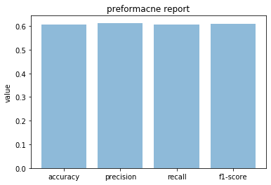

```python
print("performance of accuracy:",accuracy)
print("performance of precision:",precision)
print("performance of recall:",recall)
print("performance of f1_score:",f1_score)

objects = ("accuracy","precision","recall","f1-score")
y_pos = np.arange(len(objects))
performance = [accuracy,precision,recall,f1_score]

plt.bar(y_pos, performance, align='center', alpha=0.5)
plt.xticks(y_pos, objects)
plt.ylabel('value')
plt.title('preformacne report')

plt.show()
```

```python
X_test.iloc[:10]
```

|  | prod_cat_code | prod_subcat_code | Total_amount | Gender_F | Gender_M | Store_type_Flagship store | Store_type_MBR | Store_type_TeleShop | Store_type_e-Shop |
| --- | --- | --- | --- | --- | --- | --- | --- | --- | --- |
| 21092 | 6 | 5 | 4038.775 | 1 | 0 | 0 | 1 | 0 | 0 |
| 21465 | 1 | 2 | 3656.445 | 1 | 0 | 0 | 0 | 0 | 1 |
| 12490 | 9 | 3 | 7226.700 | 1 | 0 | 0 | 0 | 1 | 0 |
| 3879 | 7 | 5 | -3348.150 | 1 | 0 | 1 | 0 | 0 | 0 |
| 14124 | 1 | 4 | 1339.260 | 0 | 1 | 0 | 0 | 0 | 1 |
| 721 | 11 | 5 | 2994.550 | 1 | 0 | 0 | 0 | 0 | 1 |
| 10283 | 10 | 5 | 742.560 | 1 | 0 | 0 | 0 | 1 | 0 |
| 13094 | 6 | 5 | 8160.425 | 0 | 1 | 0 | 0 | 0 | 1 |
| 4190 | 6 | 5 | 1403.350 | 0 | 1 | 0 | 0 | 0 | 1 |
| 3594 | 3 | 1 | -508.300 | 1 | 0 | 0 | 0 | 0 | 1 |

##### Visualizing Decision Trees

[figure not shown]

```python
from sklearn.tree import plot_tree
decision_tree = DecisionTreeClassifier() #max_depth is maximum number of levels in the tree
decision_tree.fit(X_test.iloc[:100],y_test.iloc[:100])

plt.figure(figsize=(60,60))
a = plot_tree(decision_tree,
              feature_names=X.columns,
              class_names=Y.columns,
              filled=True,
              rounded=True,
              fontsize=14)
```

### Q4:

1. You are required to write code to find frequent itemsets using the above dataset (Question 1). In order to achieve the task, you are going to cover the following steps:
   - Importing required libraries
   - Creating a list from dataset (Question 1)
   - Convert list to dataframe with boolean values
   - Find frequently occurring itemsets using Apriori Algorithm
   - Find frequently occurring itemsets using F-P Growth
   - Mine the Association Rules

##### Importing required libraries

```python
import pandas as pd
import numpy as np
from pandas import DataFrame
import seaborn as sns
from mlxtend.frequent_patterns import apriori, association_rules
import pyfpgrowth
```

##### Creating a list from dataset

```python
# view data
itemsets = df[["customer_id","Store_type"]]
itemsets.head()
```

|  | customer_id | Store_type |
| --- | --- | --- |
| 0 | 270351 | e-Shop |
| 1 | 270384 | e-Shop |
| 2 | 273420 | TeleShop |
| 3 | 271509 | e-Shop |
| 4 | 273420 | TeleShop |

```python
itemsets.head()
```

|  | customer_id | Store_type |
| --- | --- | --- |
| 0 | 270351 | e-Shop |
| 1 | 270384 | e-Shop |
| 2 | 273420 | TeleShop |
| 3 | 271509 | e-Shop |
| 4 | 273420 | TeleShop |

```python
itemsets=itemsets.drop_duplicates(['customer_id','Store_type'],keep='first')
```

##### Creating a list from dataset

```python
# list for Apriori Algorithm
relationship=(itemsets.groupby(['customer_id','Store_type']).
              size().unstack().reset_index().fillna(0).set_index('customer_id'))
relationship.iloc[0:10,:]
```

| Store_type customer_id | Flagship store | MBR | TeleShop | e-Shop |
| --- | --- | --- | --- | --- |
| 266783 | 0.0 | 0.0 | 1.0 | 1.0 |
| 266784 | 1.0 | 0.0 | 1.0 | 1.0 |
| 266785 | 1.0 | 0.0 | 1.0 | 1.0 |
| 266788 | 1.0 | 1.0 | 0.0 | 1.0 |
| 266794 | 1.0 | 1.0 | 1.0 | 1.0 |
| 266799 | 1.0 | 0.0 | 0.0 | 1.0 |
| 266803 | 0.0 | 0.0 | 0.0 | 1.0 |
| 266804 | 0.0 | 0.0 | 0.0 | 1.0 |
| 266805 | 0.0 | 0.0 | 0.0 | 1.0 |
| 266806 | 1.0 | 0.0 | 0.0 | 1.0 |

```python
# list for F-P Growth
itemsets2= itemsets.copy()
itemsets2['Store_type'] = itemsets2['Store_type'].apply(lambda x:[x])

df_group = itemsets2.groupby(['customer_id'])['Store_type'].apply(sum).reset_index()

df_group
```

|  | customer_id | Store_type |
| --- | --- | --- |
| 0 | 266783 | [e-Shop, TeleShop] |
| 1 | 266784 | [Flagship store, e-Shop, TeleShop] |
| 2 | 266785 | [TeleShop, Flagship store, e-Shop] |
| 3 | 266788 | [e-Shop, MBR, Flagship store] |
| 4 | 266794 | [e-Shop, TeleShop, Flagship store, MBR] |
| 5 | 266799 | [Flagship store, e-Shop] |
| 6 | 266803 | [e-Shop] |
| 7 | 266804 | [e-Shop] |
| 8 | 266805 | [e-Shop] |
| 9 | 266806 | [e-Shop, Flagship store] |
| 10 | 266807 | [e-Shop, MBR, Flagship store] |
| 11 | 266809 | [MBR, e-Shop, TeleShop] |
| 12 | 266810 | [e-Shop, TeleShop] |
| 13 | 266812 | [TeleShop, MBR] |
| 14 | 266813 | [MBR] |
| 15 | 266814 | [MBR, Flagship store, e-Shop, TeleShop] |
| 16 | 266815 | [TeleShop, e-Shop, MBR] |
| 17 | 266816 | [e-Shop, TeleShop, Flagship store] |
| 18 | 266817 | [MBR, e-Shop, TeleShop] |
| 19 | 266818 | [e-Shop, TeleShop, MBR] |
| 20 | 266819 | [Flagship store, e-Shop] |
| 21 | 266820 | [Flagship store, e-Shop] |
| 22 | 266821 | [TeleShop, MBR] |
| 23 | 266822 | [e-Shop, TeleShop, Flagship store] |
| 24 | 266823 | [Flagship store, TeleShop] |
| 25 | 266824 | [MBR, TeleShop, e-Shop] |
| 26 | 266825 | [MBR, e-Shop] |
| 27 | 266827 | [TeleShop, Flagship store, e-Shop] |
| 28 | 266829 | [MBR, e-Shop] |
| 29 | 266830 | [MBR, TeleShop, e-Shop] |
| ... | ... | ... |
| 5476 | 275222 | [MBR, e-Shop] |
| 5477 | 275224 | [e-Shop, Flagship store, MBR] |
| 5478 | 275225 | [MBR, e-Shop, TeleShop] |
| 5479 | 275226 | [TeleShop, Flagship store, MBR, e-Shop] |
| 5480 | 275227 | [MBR, e-Shop, TeleShop] |
| 5481 | 275228 | [TeleShop] |
| 5482 | 275229 | [e-Shop, TeleShop] |
| 5483 | 275230 | [e-Shop, MBR] |
| 5484 | 275231 | [e-Shop, TeleShop, MBR] |
| 5485 | 275232 | [e-Shop] |
| 5486 | 275233 | [e-Shop, Flagship store] |
| 5487 | 275236 | [e-Shop] |
| 5488 | 275237 | [Flagship store] |
| 5489 | 275241 | [Flagship store, e-Shop] |
| 5490 | 275242 | [e-Shop] |
| 5491 | 275243 | [TeleShop, e-Shop] |
| 5492 | 275244 | [TeleShop, Flagship store, MBR] |
| 5493 | 275245 | [MBR, e-Shop, Flagship store] |
| 5494 | 275246 | [e-Shop, TeleShop, Flagship store] |
| 5495 | 275247 | [Flagship store, TeleShop, e-Shop] |
| 5496 | 275249 | [Flagship store, TeleShop, e-Shop] |
| 5497 | 275250 | [e-Shop, MBR] |
| 5498 | 275251 | [MBR, e-Shop] |
| 5499 | 275252 | [TeleShop, e-Shop, Flagship store, MBR] |
| 5500 | 275255 | [e-Shop] |
| 5501 | 275257 | [e-Shop, MBR] |
| 5502 | 275261 | [MBR, e-Shop, TeleShop] |
| 5503 | 275262 | [Flagship store, MBR] |
| 5504 | 275264 | [e-Shop, TeleShop] |
| 5505 | 275265 | [Flagship store, e-Shop, TeleShop] |

5506 rows × 2 columns

##### Convert list to dataframe with boolean values

```python
relationship=(itemsets.groupby(['customer_id','Store_type']).
              size().unstack().reset_index().fillna(0).set_index('customer_id')).replace({0.0:False,1.0:True})
relationship.iloc[0:10,:]
```

| Store_type customer_id | Flagship store | MBR | TeleShop | e-Shop |
| --- | --- | --- | --- | --- |
| 266783 | False | False | True | True |
| 266784 | True | False | True | True |
| 266785 | True | False | True | True |
| 266788 | True | True | False | True |
| 266794 | True | True | True | True |
| 266799 | True | False | False | True |
| 266803 | False | False | False | True |
| 266804 | False | False | False | True |
| 266805 | False | False | False | True |
| 266806 | True | False | False | True |

##### Find frequently occurring itemsets using Apriori Algorithm

```python
frequent=apriori(relationship,min_support=0.05,use_colnames=True)

frequent.sort_values(by='support',ascending=False).head(10)
```

|  | support | itemsets |
| --- | --- | --- |
| 3 | 0.792953 | (e-Shop) |
| 1 | 0.544860 | (MBR) |
| 0 | 0.534145 | (Flagship store) |
| 2 | 0.528878 | (TeleShop) |
| 8 | 0.424446 | (MBR, e-Shop) |
| 9 | 0.408645 | (TeleShop, e-Shop) |
| 6 | 0.407374 | (e-Shop, Flagship store) |
| 7 | 0.286233 | (TeleShop, MBR) |
| 4 | 0.283509 | (MBR, Flagship store) |
| 5 | 0.271704 | (TeleShop, Flagship store) |

##### Find frequently occurring itemsets using F-P Growth

```python
df_group.Store_type.head()
```

```
0                         [e-Shop, TeleShop]
1         [Flagship store, e-Shop, TeleShop]
2         [TeleShop, Flagship store, e-Shop]
3              [e-Shop, MBR, Flagship store]
4    [e-Shop, TeleShop, Flagship store, MBR]
Name: Store_type, dtype: object
```

```python
import pyfpgrowth

FP_patterns = pyfpgrowth.find_frequent_patterns(df_group.Store_type, 2)
```

```python
print("Patterns")
FP_patterns
```

```
Patterns
```

```
{('Flagship store', 'MBR', 'TeleShop'): 794,
 ('Flagship store', 'MBR', 'TeleShop', 'e-Shop'): 618,
 ('Flagship store', 'TeleShop', 'e-Shop'): 1136,
 ('MBR', 'TeleShop'): 1576,
 ('MBR', 'TeleShop', 'e-Shop'): 1233,
 ('TeleShop', 'e-Shop'): 2250,
 ('Flagship store', 'MBR'): 1561,
 ('Flagship store', 'MBR', 'e-Shop'): 1205,
 ('Flagship store', 'e-Shop'): 2243,
 ('MBR',): 3000,
 ('MBR', 'e-Shop'): 2337,
 ('e-Shop',): 4366}
```

##### Mine the Association Rules

- **using F-P growth frequency results to generate rules**

```python
rules = pyfpgrowth.generate_association_rules(FP_patterns, 0.6)

print("Rules")
rules
```

```
Rules
```

```
{('Flagship store', 'MBR', 'TeleShop'): (('e-Shop',), 0.7783375314861462),
 ('MBR', 'TeleShop'): (('e-Shop',), 0.7823604060913706),
 ('Flagship store', 'MBR'): (('e-Shop',), 0.7719410634208841),
 ('MBR',): (('e-Shop',), 0.779)}
```

- **using Apriori Algorithm result to generate rules**

```python
rules=association_rules(frequent,metric='lift',min_threshold=0.8)
#The results have been sorted using lift attribute. Lift is the confidence divided by expected confidence.
rules.sort_values("lift",ascending=False)
```

|  | antecedents | consequents | antecedent support | consequent support | support | confidence | lift | leverage | conviction |
| --- | --- | --- | --- | --- | --- | --- | --- | --- | --- |
| 34 | (MBR) | (TeleShop, e-Shop) | 0.544860 | 0.408645 | 0.223938 | 0.411000 | 1.005763 | 0.001283 | 1.003998 |
| 31 | (TeleShop, e-Shop) | (MBR) | 0.408645 | 0.544860 | 0.223938 | 0.548000 | 1.005763 | 0.001283 | 1.006947 |
| 38 | (TeleShop, e-Shop, Flagship store) | (MBR) | 0.206320 | 0.544860 | 0.112241 | 0.544014 | 0.998447 | -0.000175 | 0.998145 |
| 47 | (MBR) | (TeleShop, e-Shop, Flagship store) | 0.544860 | 0.206320 | 0.112241 | 0.206000 | 0.998447 | -0.000175 | 0.999597 |
| 33 | (TeleShop) | (MBR, e-Shop) | 0.528878 | 0.424446 | 0.223938 | 0.423420 | 0.997583 | -0.000542 | 0.998221 |
| 32 | (MBR, e-Shop) | (TeleShop) | 0.424446 | 0.528878 | 0.223938 | 0.527599 | 0.997583 | -0.000542 | 0.997294 |
| 6 | (TeleShop) | (MBR) | 0.528878 | 0.544860 | 0.286233 | 0.541209 | 0.993299 | -0.001931 | 0.992041 |
| 7 | (MBR) | (TeleShop) | 0.544860 | 0.528878 | 0.286233 | 0.525333 | 0.993299 | -0.001931 | 0.992533 |
| 35 | (e-Shop) | (TeleShop, MBR) | 0.792953 | 0.286233 | 0.223938 | 0.282410 | 0.986641 | -0.003032 | 0.994672 |
| 30 | (TeleShop, MBR) | (e-Shop) | 0.286233 | 0.792953 | 0.223938 | 0.782360 | 0.986641 | -0.003032 | 0.951329 |
| 20 | (e-Shop, Flagship store) | (MBR) | 0.407374 | 0.544860 | 0.218852 | 0.537227 | 0.985990 | -0.003110 | 0.983505 |
| 21 | (MBR) | (e-Shop, Flagship store) | 0.544860 | 0.407374 | 0.218852 | 0.401667 | 0.985990 | -0.003110 | 0.990462 |
| 9 | (e-Shop) | (MBR) | 0.792953 | 0.544860 | 0.424446 | 0.535273 | 0.982404 | -0.007603 | 0.979369 |
| 8 | (MBR) | (e-Shop) | 0.544860 | 0.792953 | 0.424446 | 0.779000 | 0.982404 | -0.007603 | 0.936864 |
| 48 | (e-Shop) | (TeleShop, MBR, Flagship store) | 0.792953 | 0.144206 | 0.112241 | 0.141548 | 0.981568 | -0.002108 | 0.996904 |
| 37 | (TeleShop, MBR, Flagship store) | (e-Shop) | 0.144206 | 0.792953 | 0.112241 | 0.778338 | 0.981568 | -0.002108 | 0.934064 |
| 11 | (e-Shop) | (TeleShop) | 0.792953 | 0.528878 | 0.408645 | 0.515346 | 0.974414 | -0.010730 | 0.972080 |
| 10 | (TeleShop) | (e-Shop) | 0.528878 | 0.792953 | 0.408645 | 0.772665 | 0.974414 | -0.010730 | 0.910756 |
| 1 | (Flagship store) | (MBR) | 0.534145 | 0.544860 | 0.283509 | 0.530772 | 0.974143 | -0.007525 | 0.969976 |
| 0 | (MBR) | (Flagship store) | 0.544860 | 0.534145 | 0.283509 | 0.520333 | 0.974143 | -0.007525 | 0.971207 |
| 16 | (MBR) | (TeleShop, Flagship store) | 0.544860 | 0.271704 | 0.144206 | 0.264667 | 0.974101 | -0.003834 | 0.990430 |
| 13 | (TeleShop, Flagship store) | (MBR) | 0.271704 | 0.544860 | 0.144206 | 0.530749 | 0.974101 | -0.003834 | 0.969928 |
| 22 | (e-Shop) | (MBR, Flagship store) | 0.792953 | 0.283509 | 0.218852 | 0.275996 | 0.973501 | -0.005957 | 0.989624 |
| 19 | (MBR, Flagship store) | (e-Shop) | 0.283509 | 0.792953 | 0.218852 | 0.771941 | 0.973501 | -0.005957 | 0.907866 |
| 43 | (MBR, e-Shop) | (TeleShop, Flagship store) | 0.424446 | 0.271704 | 0.112241 | 0.264442 | 0.973272 | -0.003082 | 0.990127 |
| 42 | (TeleShop, Flagship store) | (MBR, e-Shop) | 0.271704 | 0.424446 | 0.112241 | 0.413102 | 0.973272 | -0.003082 | 0.980670 |
| 46 | (TeleShop) | (MBR, e-Shop, Flagship store) | 0.528878 | 0.218852 | 0.112241 | 0.212225 | 0.969720 | -0.003505 | 0.991588 |
| 39 | (MBR, e-Shop, Flagship store) | (TeleShop) | 0.218852 | 0.528878 | 0.112241 | 0.512863 | 0.969720 | -0.003505 | 0.967125 |
| 44 | (MBR, Flagship store) | (TeleShop, e-Shop) | 0.283509 | 0.408645 | 0.112241 | 0.395900 | 0.968811 | -0.003613 | 0.978902 |
| 41 | (TeleShop, e-Shop) | (MBR, Flagship store) | 0.408645 | 0.283509 | 0.112241 | 0.274667 | 0.968811 | -0.003613 | 0.987809 |
| 18 | (MBR, e-Shop) | (Flagship store) | 0.424446 | 0.534145 | 0.218852 | 0.515618 | 0.965316 | -0.007863 | 0.961753 |
| 23 | (Flagship store) | (MBR, e-Shop) | 0.534145 | 0.424446 | 0.218852 | 0.409725 | 0.965316 | -0.007863 | 0.975060 |
| 45 | (e-Shop, Flagship store) | (TeleShop, MBR) | 0.407374 | 0.286233 | 0.112241 | 0.275524 | 0.962585 | -0.004363 | 0.985218 |
| 40 | (TeleShop, MBR) | (e-Shop, Flagship store) | 0.286233 | 0.407374 | 0.112241 | 0.392132 | 0.962585 | -0.004363 | 0.974926 |
| 5 | (Flagship store) | (e-Shop) | 0.534145 | 0.792953 | 0.407374 | 0.762666 | 0.961804 | -0.016178 | 0.872385 |
| 4 | (e-Shop) | (Flagship store) | 0.792953 | 0.534145 | 0.407374 | 0.513743 | 0.961804 | -0.016178 | 0.958043 |
| 2 | (TeleShop) | (Flagship store) | 0.528878 | 0.534145 | 0.271704 | 0.513736 | 0.961793 | -0.010793 | 0.958030 |
| 3 | (Flagship store) | (TeleShop) | 0.534145 | 0.528878 | 0.271704 | 0.508671 | 0.961793 | -0.010793 | 0.958873 |
| 15 | (TeleShop) | (MBR, Flagship store) | 0.528878 | 0.283509 | 0.144206 | 0.272665 | 0.961751 | -0.005735 | 0.985091 |
| 14 | (MBR, Flagship store) | (TeleShop) | 0.283509 | 0.528878 | 0.144206 | 0.508648 | 0.961751 | -0.005735 | 0.958829 |
| 25 | (TeleShop, Flagship store) | (e-Shop) | 0.271704 | 0.792953 | 0.206320 | 0.759358 | 0.957633 | -0.009128 | 0.860395 |
| 28 | (e-Shop) | (TeleShop, Flagship store) | 0.792953 | 0.271704 | 0.206320 | 0.260192 | 0.957633 | -0.009128 | 0.984440 |
| 27 | (TeleShop) | (e-Shop, Flagship store) | 0.528878 | 0.407374 | 0.206320 | 0.390110 | 0.957622 | -0.009130 | 0.971693 |
| 26 | (e-Shop, Flagship store) | (TeleShop) | 0.407374 | 0.528878 | 0.206320 | 0.506465 | 0.957622 | -0.009130 | 0.954587 |
| 29 | (Flagship store) | (TeleShop, e-Shop) | 0.534145 | 0.408645 | 0.206320 | 0.386263 | 0.945229 | -0.011955 | 0.963532 |
| 24 | (TeleShop, e-Shop) | (Flagship store) | 0.408645 | 0.534145 | 0.206320 | 0.504889 | 0.945229 | -0.011955 | 0.940911 |
| 17 | (Flagship store) | (TeleShop, MBR) | 0.534145 | 0.286233 | 0.144206 | 0.269976 | 0.943204 | -0.008684 | 0.977731 |
| 12 | (TeleShop, MBR) | (Flagship store) | 0.286233 | 0.534145 | 0.144206 | 0.503807 | 0.943204 | -0.008684 | 0.938860 |
| 49 | (Flagship store) | (TeleShop, MBR, e-Shop) | 0.534145 | 0.223938 | 0.112241 | 0.210133 | 0.938354 | -0.007374 | 0.982522 |
| 36 | (TeleShop, MBR, e-Shop) | (Flagship store) | 0.223938 | 0.534145 | 0.112241 | 0.501217 | 0.938354 | -0.007374 | 0.933983 |